# DRAFT Analysis of the GHG Emissions Implications of the Income Patterns of New Development

Nathaniel Decker

8/21/2017

## Introduction

This is a project undertaken as part of the Data Science for the 21<sup>st</sup> Century (DS421) National Science Foundation Research Traineeship. Specifically, it is a “Research Experience for Trainees,” a required part of the DS421 program where the trainee contributes to research “outside of their primary discipline” for 50% of a summer. This particular project builds off of work previously performed by the author, Nathaniel Decker, (Decker et al., 2017) and the research sponsor, Christopher Jones (Jones & Kammen, 2014, 2015).

The research examines the interplay of household income and geography on household greenhouse gas (GHG) footprints. Jones & Kammen (2014) have shown that the income of households has a dramatic impact on the effect of geography on households’ GHG footprints. High-income households in dense, accessible neighborhoods have a far lower GHG footprint than high-income households in far-flung exurbs, and this difference is much greater than the difference between low-income households in dense versus exurban areas. The actions of local governments have a profound impact on the patterns of new housing construction by the income of the population that moves into the units (Glaeser, Gyourko, & Saks, 2005; Terner Center for Housing Innovation, n.d.). The order-of-magnitude GHG effect of the siting of new housing in California has been shown (Decker et al., 2017; Jones & Kammen, 2015), but the extent to which these impacts vary by the geographic patterns of the incomes of the households that move to those units is unknown. This is an important policy concern because the means of facilitating the development of income-restricted (or “affordable”) housing are very different than the means of facilitating the development of market-rate housing.

While the GHG implications of siting affordable housing are extensively debated and have a major role in the funding of affordable housing, the GHG implications of the siting of new market-rate housing have not resulted in major policy changes or new programs that effectively spur market-rate development in infill areas across the state. The raison d’etre of the largest state source of affordable housing funding, the Affordable Housing and Sustainable Communities Program, is GHG reduction. The criteria for awards of the largest federal source of funding for affordable housing construction, the Low Income Housing Tax Credit, have been revised in California to lower the GHG emissions of these subsidized households. While some state processes to plan for and promote the construction of market rate housing do consider the GHG emissions impact of the siting of new market-rate housing, these measures are largely ineffective (Dillon 2017).

The calculation of the GHG reduction potential stratified by household income can be used to understand this pressing policy issue. This calculation should help clarify the GHG emissions payoff of regulatory changes to facilitate market-rate housing generation in infill areas.

## Analysis

This analysis estimates how much the income patterns of new development matter by comparing two scenarios underlain by a set of assumptions about the next five years of residential development in the state of California. We assume that the next five years of residential development in California follows the geographic patterns of the last five years. We assume that the income mix of the new residents of the state roughly matches the current income mix of the regions of the state they move to. We assume that the total regional volume of the population increase preducted by the state Department of Finance is correct. One of the most important assumptions in this analysis is an attempt to disentangle the major drivers of household ghg emissions: income, unit characteristics, and location of residence. All three of these variables are inter-related, but this analysis aims to isolate the effect of income alone. To do so this analysis assumes that new households and units in an area roughly mirror the existing residents and units of an area, controlling for income. This means that new market-rate units look roughly-like the existing units occupied by higher-ncome households and will be occupied by moderate-to-high income households themselves that have roughly the same characterisitics as existing moderate-to-high income residentis in the area. Given these assumptions we consider two scenarios:

1. **Market Rate Infill Scenario**: where development of infill market-rate housing is facilitated to the point where all market-rate housing is placed in infill areas and income-restricted housing is constructed in farther-flung locations and,
2. **Affordable Infill Scenario**: where subsidies for income-resticted housing are vastly increased and all of this housing is constructed in infill areas, but no policies are put in place to facilitate the development of new market-rate units in infill areas and this higher cost housing is largely constructed in suburban and exurban areas.

The analysis isolates the impact of income patterns by geography. It also acknolwedges that, while the affordable housing development system in California promotes the GHG-resposible siting of housing, this goal has not yet been actualized in the various systems for market-rate development. While efforts have been made to push municipalities to adjust their land use regulations to facilitate the GHG-resposible development of new housing supply (particularly the state’s requirements for Regional Housing Needs Allocations (RHNA), Annual Progress Reports (APRs), and housing elements in comprehensive plans), these systems have failed to generate a set of policies at the local level to facilitate the development of infill market-rate housing (and have also limited the infill development of subsidized housing).

## Results

The California Department of Finance projects that the state will add 1,660,190 new residents in approximately 628,545 households over the next five years. This analysis assumes that this growth will be accomodated with new housing construction and that this volume will roughly follow the regional patterns predicted by the Department of Finance. Within each region we assume the neighborhood patterns of residential construction will reflect the patterns of the past 5 years.

In this analysis there is no difference in the location of new development between the two scenarios. The maps below shows the similarity between the scenarios. The outlines within the state show the study areas to which households are allocated (these are “public use microdata areas” or “PUMAs,” designated by the Census). The orange circles represent the number of new units added to each area. The maps show that the geographic pattern of development is nearly identical in the scenarios. (Though not exactly identical — differences arise because the scenarios place the same number of *people* in each area. The number of *units* that this population translates to will vary depending on the income of the new residents.) Put simply, in both scenarios the same sites are developed in the same cities and suburbs.

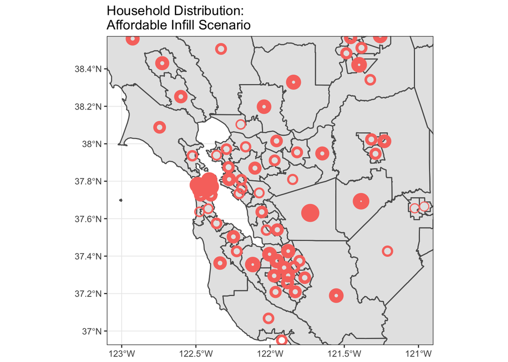

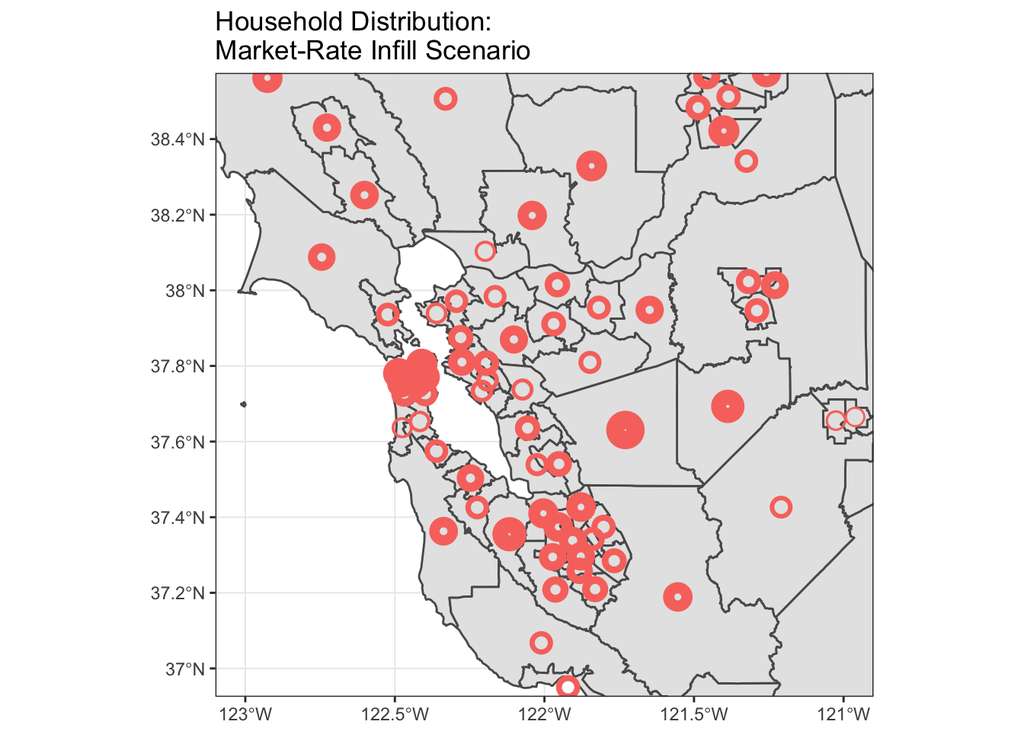

The differences between the scenarios arises from the unit characteristics of the buildings that are developed, and whether the buildings are income-restricted or market-rate. The maps below show the differences in the pattern of incomes in the affordable infill scenario in the San Francisco Bay Area. Once again the size of the orange circles indicates the the number of new units developed in each area. The areas are also color-coded to show the average per-household GHG footprint for the relevant income level, with darker blue indicating smaller per-person GHG footprints. and lighter blue indicating larger GHG footprints. In this scenario the lowest income households are concentrated in the densest, most transit-rich, and lowest GHG-intensive areas of the region: San Francisco and the central city areas of the other major Bay Area cities of Oakland, Hayward, Richmond, and San Jose. With these infill sites “taken up” by affordable development in this scenario, higher income households are crowded out of the lowest GHG areas of the Bay area and are developed in suburban and exurban areas.

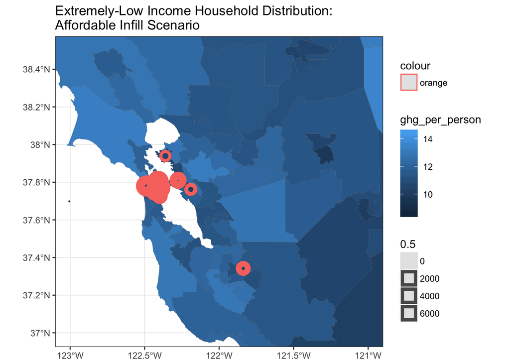

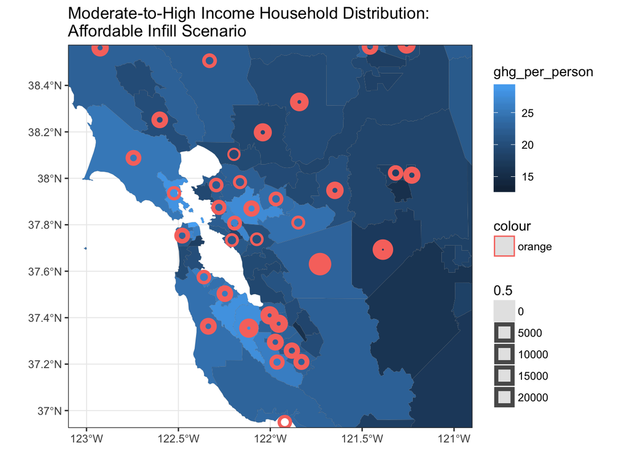

The maps also reveal an interesting, but incidental, finding of the analysis — that, controlling for household incomes, the GHG intensity of areas varies by income category. The general direction of the impact of income and geogaphy are as expected: central cities tend to have the smallest per-person GHG footprints, while suburban and exurban areas tend to have the largest footprints, and income has a powerful impact on consumption levels which in turn has a big impact on GHG footprints. The general direction of the influence of geography is complicated slightly when considering different income bands. For example, within Marin County the lowest per-person GHG footprints are in the denser areas around San Rafael for the lowest-income households, but the denser areas of Marin actually have slightly higher per-person GHG footprints for higher-income households.

The table below summarizes the results of the analysis, showing the total volume of emissions, the total number of households, and the per-household emissions by income band in the two scenarios.

| Income Category | Emissions: Market Infill (1,000s) | Emissions: Affordable Infill (1,000s) | Households: Market Infill (1,000s) | Households: Affordable Infill (1,000s) | Per-HH Emissions: Market Infill | Per-HH Emissions: Affordable Infill |
| --- | --- | --- | --- | --- | --- | --- |
| MOD2HI | 17,290 | 19,757 | 303 | 344 | 57.0 | 57.5 |
| SLI | 3,850 | 3,739 | 111 | 93 | 34.8 | 40.4 |
| VLI | 2,752 | 2,408 | 90 | 67 | 30.6 | 36.0 |
| XLI | 3,129 | 2,396 | 137 | 99 | 22.8 | 24.1 |
| Total | 27,021 | 28,300 | 641 | 603 | 36.3 | 39.5 |

The market-rate infill scenario results in -4.5% less total household emissions than a priority affordable infill scenario. As expected the GHG reductions arising from siting development for higher-income families in infill areas are larger than those arising from siting lower-income families in infill areas. Interestingly, the average household size (and therefore unit size) in the market-rate infill scenario is substantially smaller than in the affordable scenario, meaning that more, but smaller units are developed.

## References

California Department of Finance. (n.d.). Demographic Projections. Retrieved July 1, 2017, from http://www.dof.ca.gov/Forecasting/Demographics/Projections/

Decker, N., Galante, C., Chapple, K., Martin, A., Elkind, E. N., & Hanson, M. (2017). Right Type, Right Place: Assessing the Environmental and Economic Impacts of Infill Residential Development through 2030. Berkeley, CA: Terner Center for Housing Innovation & Center for Law, Energy and the Environment (CLEE). Retrieved from http://next10.org/right-housing

Dillon, L. (2017, June 29). California lawmakers have tried for 50 years to fix the state’s housing crisis. Here’s why they’ve failed. Los Angeles Times. Retrieved from http://www.latimes.com/projects/la-pol-ca-housing-supply/

Glaeser, E. L., Gyourko, J., & Saks, R. (2005). Why Is Manhattan So Expensive? Regulation and the Rise in Housing Prices. The Journal of Law and Economics, 48(2), 331–369. https://doi.org/10.1086/429979

Jones, C. M., & Kammen, D. M. (2014). Spatial Distribution of U.S. Household Carbon Footprints Reveals Suburbanization Undermines Greenhouse Gas Benefits of Urban Population Density. Environmental Science & Technology, 48(2), 895–902. https://doi.org/10.1021/es4034364

Jones, C. M., & Kammen, D. M. (2015). A Consumption-Based Greenhouse Gas Inventory of San Francisco Bay Area Neighborhoods, Cities and Counties: Prioritizing Climate Action for Different Locations. Bay Area Air Quality Management District. Retrieved from http://escholarship.org/uc/item/2sn7m83z

Terner Center for Housing Innovation. (n.d.). Housing Development Dashboard. Retrieved July 1, 2017, from https://ternercenter.berkeley.edu/dashboard